# Money Ball

**This homework is due Sunday March 27, 2016 at 11:59PM EST. When complete, submit your code in an R Markdown file and the knitted HTML via GitHub.**

# Introduction

*Moneyball: The Art of Winning an Unfair Game* is a book by Michael Lewis about the Oakland Athletics baseball team and its general manager, the person tasked with building the team, Billy Beane. During Billy Bean’s tenure as general manager, ownership cut the budget drastically leaving Billy Bean with one of the lowest payrolls in baseball. Money Ball tells the story of how Billy Bean used analysts to find inefficiencies in the market. Specifically, his team used data science to find low cost players that the data predicted would help the team win. In this lab we will go back to 2002 and try to build a baseball team with a limited budget of $50,000,000. Note that in contrast to that Oakland A’s, the Yankees had a [budget](http://www.baseballchronology.com/Baseball/Years/2002/Payroll.asp) of more than double: $125,000,000

We will use the `Lahman` library as well as the usual `dplyr` and `ggplot2`. We also introduce the package `broom`.

```r
library(Lahman)
library(dplyr)
library(ggplot2)
library(broom)
#Convert statistical analysis objects from R into tidy data frames,so that they can more easily be combined, reshaped and processed with tools like dplyr, tidyr, and ggplot2
# https://cran.r-project.org/web/packages/broom/broom.pdf
```

You can see tables that are available when you load this package by typing

```r
?Lahman
```

# Problem 1 (80% of grade)

Statistics have been used in baseball since its beginnings. Note that `Lahman` goes back to the 19th century. Batting average, for example, has been used to summarize a batter’s success for decades. [Other statistics](http://mlb.mlb.com/stats/league_leaders.jsp) such as home runs, runs batted in (RBI) and stolen bases have been reported and players rewarded for high numbers. However, until [Bill James](https://en.wikipedia.org/wiki/Bill_James) introduced [sabermetrics](https://en.wikipedia.org/wiki/Sabermetrics), careful analyses had not been done to determine if these statistics actually help a team win. To simplify the exercise we will focus on scoring runs and ignore pitching and fielding.

## Problem 1A

Use the data in the `Team` table to explore the relationship between stolen bases and runs per game in 1999. Make a plot, fit a regression line, and report the coefficients. If you take the coefficient at face value, how many more runs per game does a team score for every extra SB per game?

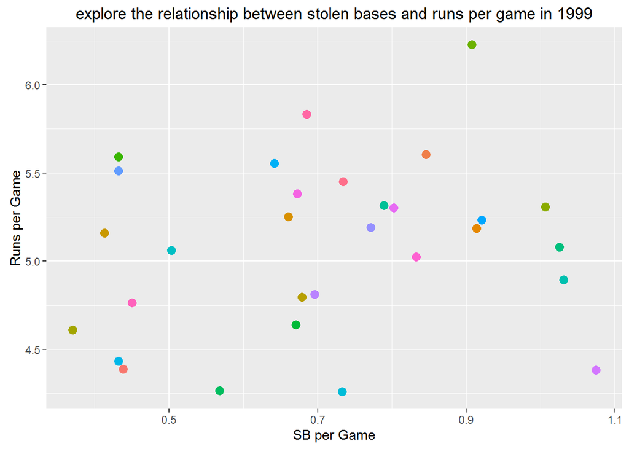

```r
# plot R per game against SB per game
Teams%>%mutate(R=R/G, SB=SB/G)%>%
        filter(yearID==1999)%>%
        ggplot(aes(x=SB,y=R,col=teamID))+
        geom_point(shape=19,size=3)+
        theme(legend.position='none')+
        ggtitle("explore the relationship between stolen bases and runs per game in 1999")+xlab("SB per Game")+ylab("Runs per Game")
```

```r
# Regression
fit <-Teams%>%
      mutate(R=R/G, SB=SB/G)%>%
      filter(yearID==1999)%>%
      lm(R~SB, data=.)

# report coefficients
summary(fit)$coefficients
```

```
##              Estimate Std. Error    t value     Pr(>|t|)
## (Intercept) 4.7818127  0.3159664 15.1339267 5.224916e-15
## SB          0.4294013  0.4308495  0.9966388 3.274754e-01
```

## Problem 1B

In Problem 1A we observed a positive relationship between scoring runs and stealing bases. However, the estimated coefficient is a random variable. Their is chance involved in scoring run. So how do we know if this observed relationship was not just chance variability?

To examine the variability of this random variable we will consider each year to be a new independent outcome. Use the `lm` and `do` functions to fit a linear model to each year since 1961 (when they started playing 162 games per year). Hint: use the function `tidy` in `broom` to process the regression in each group so that it can be recombined (see [here](https://cran.r-project.org/web/packages/broom/vignettes/broom_and_dplyr.html) for examples).

Using this approach what is your estimate of the random variable’s standard error? Is the distribution of the random variable well approximated by a normal distribution? If so, use this to provide a 95% confidence interval for our effect of stolen bases on runs per game. Do you think stolen bases help score runs?

```r
# regression stratified by year
fit<- Teams%>%
      mutate(R=R/G, SB=SB/G)%>%
      filter(yearID>=1961)%>%
      group_by(yearID)%>%
      do(tidy(lm(formula=R~SB, data=.)))%>%
      ungroup()%>%
      filter(term=='SB')


# The standard error of linear regression coefficient
stat <- fit%>%summarise(mean=mean(estimate),sd=sd(estimate))
stat
```

```
## Source: local data frame [1 x 2]
##
##         mean        sd
##        (dbl)     (dbl)
## 1 0.03405288 0.4125252
```

> Using this approach, my estimate of the random variable’s (effect of SB on R per game) standard error is 0.4125252.

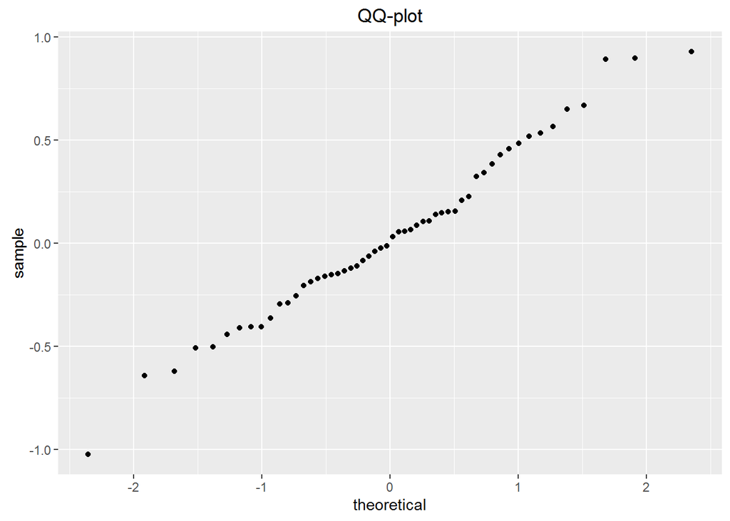

```r
# Make a QQ-plot to examine Normality
fit%>%ggplot()+stat_qq(aes(sample=estimate))+ggtitle("QQ-plot")
```

From the QQ-plot, the random quantity we are interested in, that is, effect of SB on Runs per game, varies yearly, but its samplying distribution is approximately normal. Hence, we can estimate 95% confidence interval using normal quantiles (0.025% and 97.5%).

```r
# 95% Confidence interval
cat("Lower 95% Confidence Limit is:", stat$mean+stat$sd*qnorm(p=0.025,mean=0,sd=1),"\n","Upper 95% Confidence Limit is:", stat$mean+stat$sd*qnorm(p=0.975,mean=0,sd=1))
```

```
## Lower 95% Confidence Limit is: -0.7744817
##  Upper 95% Confidence Limit is: 0.8425875
```

> From the confidence interval, we see that the effect of SB on Runs per game, could be either positive or negative; in other words, it positive we observed in previous question could be just due to chances.

## Problem 1C

Even if we didn’t have several years to examine the distribution of our estimate, there is a version of CLT that applies to regression. It turns out that with a large enough sample size, in this case the number of teams, we can construct a confidence interval. Use the function `tidy` to report a confidence interval for the effect of SB on runs based exclusively on the 1999 data. What are your thoughts now on the effectiveness of recruiting players that can steal bases?

```r
Teams%>%
      mutate(R=R/G, SB=SB/G)%>%
      filter(yearID==1999)%>%
      lm(formula=R~SB, data=.)%>%
      confint()
```

```
##                  2.5 %   97.5 %
## (Intercept)  4.1345848 5.429041
## SB          -0.4531538 1.311956
```

> Same as Problem 1B, from the confidence interval estimated based on 1999 data exclusively, we see that the effect of SB on Runs per game could be either positive or negative. My thoughts is that, recruiting players that can steal bases is not effective on Runs scored, the positive effect of stolen bases on runs we observed from estimate based on single year (1999) data is highly likely due to chances alone.

## Problem 1D

Back in 2002, bases on balls (BB) did not receive as much attention as other statistics. Repeat the above analysis we performed for SB for BB per game. Do BB have larger effect on runs than SB?

```r
fit <-Teams%>%
      mutate(R=R/G, BB=BB/G)%>%
      filter(yearID==1999)%>%
      lm(formula=R~BB, data=.)
# report effect estimate
summary(fit)$coefficients
```

```
##              Estimate Std. Error  t value     Pr(>|t|)
## (Intercept) 3.0703450  0.5095335 6.025796 1.707413e-06
## BB          0.5466818  0.1369469 3.991925 4.294019e-04
```

```r
# report confidence interval
confint(fit)
```

```
##                 2.5 %    97.5 %
## (Intercept) 2.0266130 4.1140770
## BB          0.2661588 0.8272048
```

> From the coefficients table, we see that BB has significant positive effect on R, 0.5467 (p-value=4.294019e-04 <.05). And from the reported confidence interval, we can see that, if repeat this analysis for a large number of years’ data, we would expect 95% of times, the effect of BB on R will fall in the interval between 0.2662 and 0.8272.

> Yes, BB do have larger positive effect on runs than SB (not significant).

## Problem 1E

Association is not causation. It turns out that HR hitters also obtain many BB. We know for a fact that HRs cause runs because, by definition, they produce at least one. We can see this by simply plotting these two statistics for all players with more than 500 plate appearances (`BB+AB`):

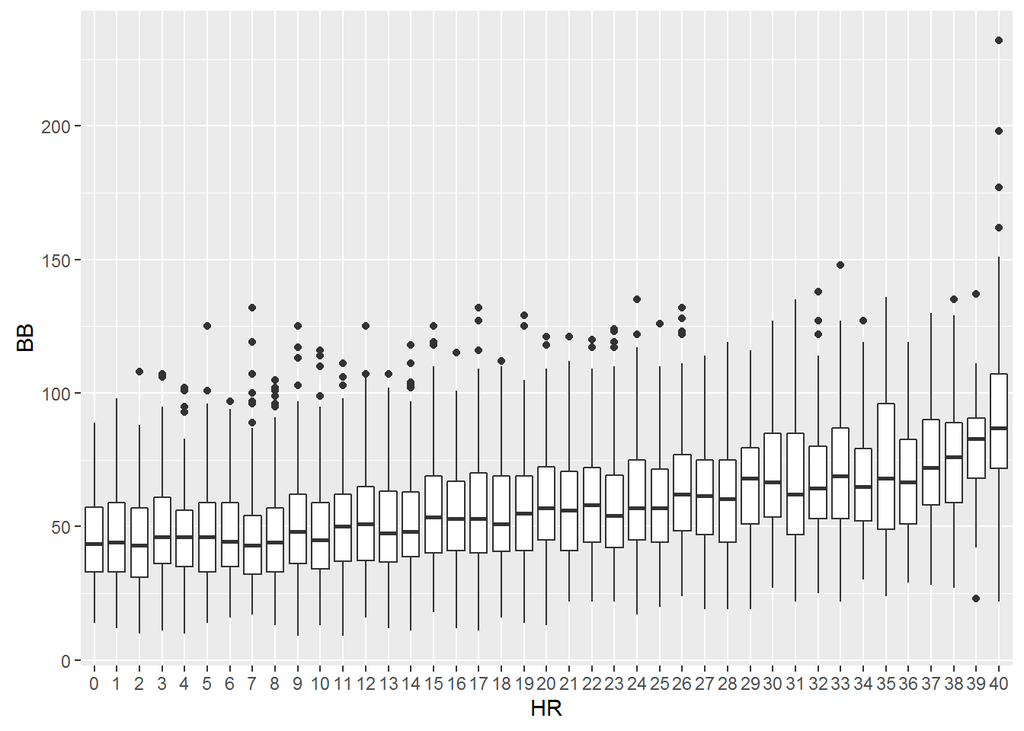

```r
Batting %>%
  filter(yearID >= 1961 & BB+AB > 500 & !is.na(HR) & !is.na(BB)) %>%
  mutate(HR = factor(pmin(HR, 40))) %>%
  ggplot(aes(HR, BB)) +
  geom_boxplot()
```

So is the relationship we saw above for BB and Runs due to teams having more HRs also having more BBs? One way we can explore this is by keeping HR fixed and examining the relationship within the strata. For example, if we only look only at teams with 150 home runs, do more BB produce more runs?

We can’t perform this analysis on a single year, because there are not enough teams to obtain strata with more than one or two teams. Instead we will combine all data years since 1961.

Group data by the number of HRs and perform a regression analysis in each stratum to determine the effect of BB per game on runs per game. Use 10th, 20th, … quantiles to split the data into 10 groups. Hint: use the function `cut` and `quantile` to create the strata.

```r
# Use 'cut' and 'quantile' to create the strata by number of HRs
dat1D<-Teams %>%
       filter(yearID >= 1961)%>%
       mutate(HR=HR/G, BB=BB/G, R=R/G)

dat1D$stratum <- cut(dat1D$HR, breaks=c(quantile(dat1D$HR,probs=seq(0,1,0.1))),labels=c("0-10%","10-20%","20-30%","30-40%","40-50%","50-60%","60-70%","70-80%","80-90%","90-100%"))

# Regression on each stratum (HR) to determine the effect of BB on Runs
dat1D%>%
    group_by(stratum)%>%
    do(tidy(lm(formula=R~BB, data=.)))%>%
    filter(term=="BB")%>%
    ungroup()
```

```
## Source: local data frame [10 x 6]
##
##    stratum  term  estimate  std.error statistic      p.value
##     (fctr) (chr)     (dbl)      (dbl)     (dbl)        (dbl)
## 1    0-10%    BB 0.5765042 0.07643861  7.542055 5.454395e-12
## 2   10-20%    BB 0.2717674 0.08386533  3.240522 1.486360e-03
## 3   20-30%    BB 0.3249864 0.08355098  3.889678 1.536842e-04
## 4   30-40%    BB 0.3501527 0.07087733  4.940263 2.192452e-06
## 5   40-50%    BB 0.2952293 0.06880996  4.290502 3.390204e-05
## 6   50-60%    BB 0.3162944 0.07365079  4.294515 3.130540e-05
## 7   60-70%    BB 0.4855139 0.07418955  6.544236 1.281302e-09
## 8   70-80%    BB 0.4441734 0.06320091  7.027958 8.419585e-11
## 9   80-90%    BB 0.4278463 0.06086063  7.029935 7.817139e-11
## 10 90-100%    BB 0.5361635 0.06419123  8.352597 6.832191e-14
```

## Problem 1F

In problem 1E we saw that the effect of BB on runs appears to be about the same in each strata. The relationship between HR and R is also, not surprisingly, linear:

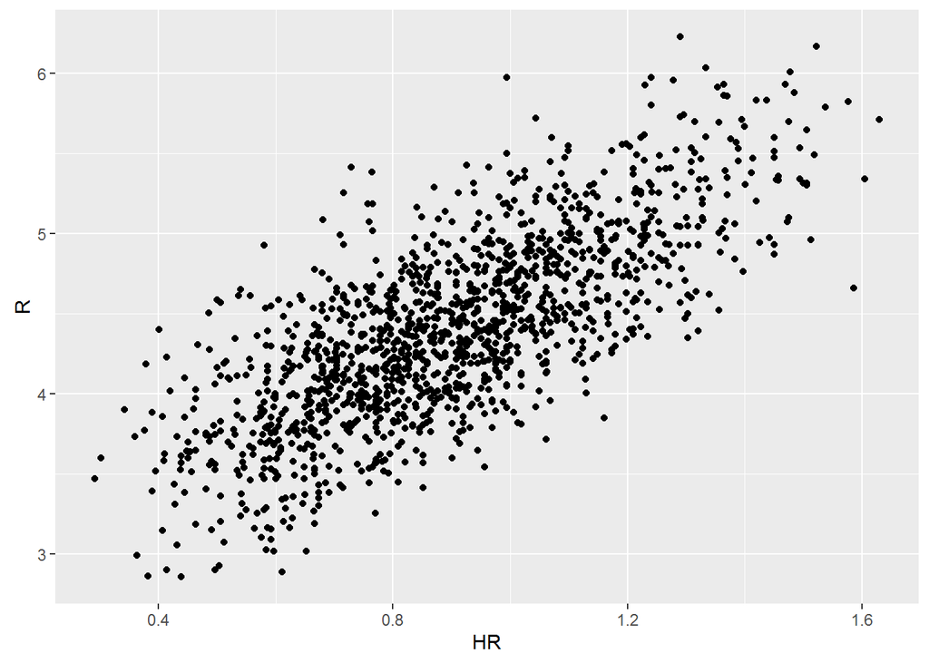

```r
Teams %>%
  filter(yearID >= 1961) %>%
  mutate(R = R / G, HR = HR / G) %>%
  ggplot(aes(HR, R)) +
  geom_point()
```

These two combined implies that a sensible linear model says:

$\mbox{Runs} = \beta_0 + \beta_{BB} \mbox{BB} + \beta_{HR}{HR} + \varepsilon$

In this model, we *adjust* for HRs by including it as linear term. Note that we have already showed data that support this model. In general, simply fitting such a model does not necessarily adjust for a possible confounded. The model must be approximately correct.

We can fit this model like this:

```r
fit <- Teams %>%
  filter(yearID >= 1961) %>%
  mutate(R = R / G, BB = BB / G, HR = HR / G) %>%
  lm(R ~ BB + HR, data = .)
summary(fit)
```

```
##
## Call:
## lm(formula = R ~ BB + HR, data = .)
##
## Residuals:
##      Min       1Q   Median       3Q      Max
## -0.94455 -0.23722 -0.01219  0.22386  1.25223
##
## Coefficients:
##             Estimate Std. Error t value Pr(>|t|)
## (Intercept)  1.74279    0.06963   25.03   <2e-16 ***
## BB           0.39985    0.02236   17.89   <2e-16 ***
## HR           1.50620    0.04006   37.60   <2e-16 ***
## ---
## Signif. codes:  0 '***' 0.001 '**' 0.01 '*' 0.05 '.' 0.1 ' ' 1
##
## Residual standard error: 0.3423 on 1413 degrees of freedom
## Multiple R-squared:  0.6421, Adjusted R-squared:  0.6416
## F-statistic:  1268 on 2 and 1413 DF,  p-value: < 2.2e-16
```

Note that the summary shows a very strong HR effect but also a decent BB effect. Now what happens if we include Singles (`H-X2B-X3B-HR`), Extra bases (doubles `X2B` and triples `X3B`), and HR per game. What does the model say about which of these characteristics should receive more weight. Fit the model to each year independently to check for consistency from year to year.

```r
# All years overall effect
fit <- Teams %>%
       filter(yearID >= 1961) %>%
       mutate(Singles=(H-X2B-X3B-HR)/G, X2B=X2B/G, X3B=X3B/G, HR = HR / G, R=R/G) %>%
      lm(R ~ Singles + X2B + X3B + HR, data = .)

summary(fit)
```

```
##
## Call:
## lm(formula = R ~ Singles + X2B + X3B + HR, data = .)
##
## Residuals:
##      Min       1Q   Median       3Q      Max
## -0.68536 -0.14669 -0.00818  0.13343  0.76748
##
## Coefficients:
##             Estimate Std. Error t value Pr(>|t|)
## (Intercept) -2.01648    0.09617  -20.97   <2e-16 ***
## Singles      0.56886    0.01453   39.15   <2e-16 ***
## X2B          0.73156    0.02550   28.69   <2e-16 ***
## X3B          1.17419    0.09366   12.54   <2e-16 ***
## HR           1.69008    0.02859   59.10   <2e-16 ***
## ---
## Signif. codes:  0 '***' 0.001 '**' 0.01 '*' 0.05 '.' 0.1 ' ' 1
##
## Residual standard error: 0.2112 on 1411 degrees of freedom
## Multiple R-squared:  0.8639, Adjusted R-squared:  0.8635
## F-statistic:  2240 on 4 and 1411 DF,  p-value: < 2.2e-16
```

> From the effect estimates, the order of characterisitcs should receive highest weight to lowest is: HR, X3B, X2B, and lastly Singles.

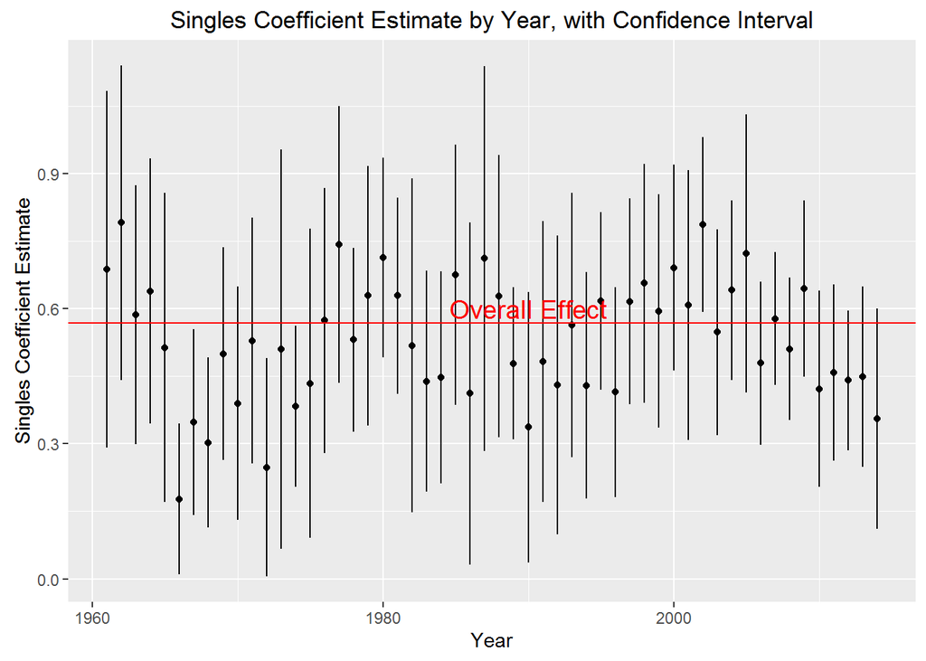

```r
# Fit the model to each year independently to check for consistency from year to year.
fit.yearly  <-Teams %>%
                    filter(yearID >= 1961) %>%
                    mutate(Singles=(H-X2B-X3B-HR)/G, X2B=X2B/G, X3B=X3B/G, HR = HR / G, R=R/G) %>%
                    group_by(yearID)%>%
                    do(tidy(lm(R ~ Singles + X2B + X3B + HR, data = .)))%>%
                    ungroup()

CI.yearly   <-Teams %>%
                    filter(yearID >= 1961) %>%
                    mutate(Singles=(H-X2B-X3B-HR)/G, X2B=X2B/G, X3B=X3B/G, HR = HR / G, R=R/G) %>%
                    group_by(yearID)%>%
                    do(tidy(confint(lm(R ~ Singles + X2B + X3B + HR, data = .))))%>%
                    ungroup()%>%
                    mutate(term=.rownames)

plot.yearly <-left_join(fit.yearly, CI.yearly, by=c("yearID","term"))



# visualize yearly results: coeffients and Confidence Interval

# Singles:
plot.yearly%>%
          filter(term=="Singles")%>%
          ggplot(aes(x=yearID,y=estimate))+
          geom_point()+
          geom_segment(aes(x = yearID, y = X2.5.., xend = yearID, yend = X97.5..))+theme(legend.position = "bottom")+
          labs(x="Year",y="Singles Coefficient Estimate",title="Singles Coefficient Estimate by Year, with Confidence Interval")+
          geom_hline(yintercept =fit$coefficients['Singles'],col="red" )+
          annotate("text", x = 1990, y = 0.6, label = "Overall Effect",col='red',size=5)
```

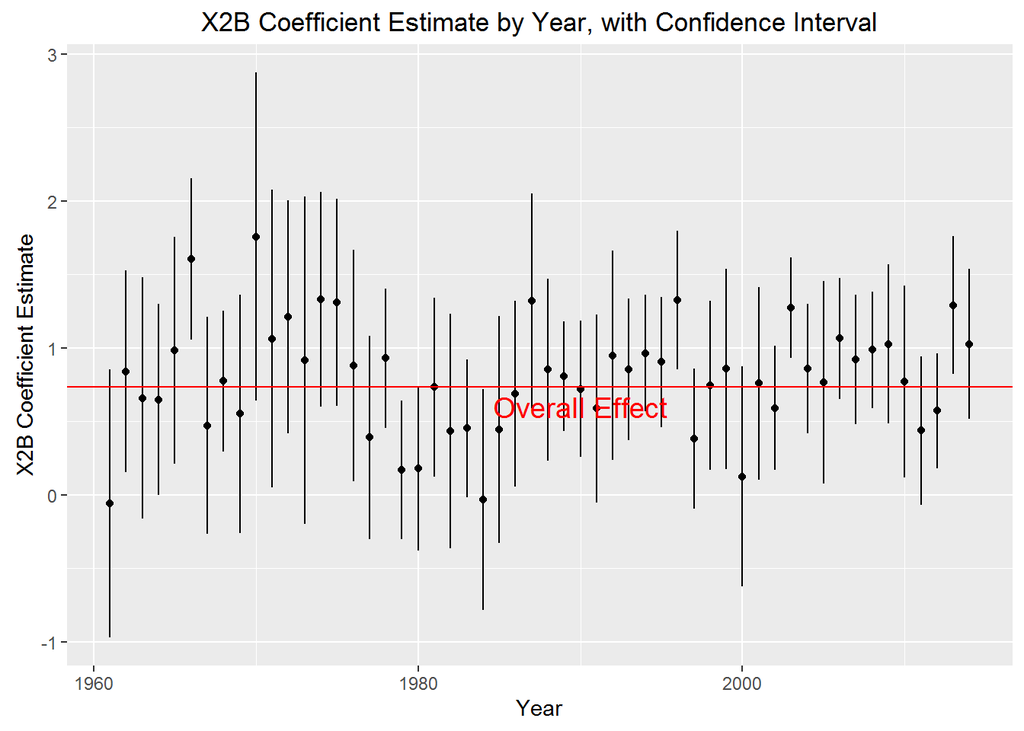

```r
# X2B:
plot.yearly%>%
          filter(term=="X2B")%>%
          ggplot(aes(x=yearID,y=estimate))+
          geom_point()+
          geom_segment(aes(x = yearID, y = X2.5.., xend = yearID, yend = X97.5..))+theme(legend.position = "bottom")+
          labs(x="Year",y="X2B Coefficient Estimate",title="X2B Coefficient Estimate by Year, with Confidence Interval")+
          geom_hline(yintercept =fit$coefficients['X2B'],col="red" )+
          annotate("text", x = 1990, y = 0.6, label = "Overall Effect",col='red',size=5)
```

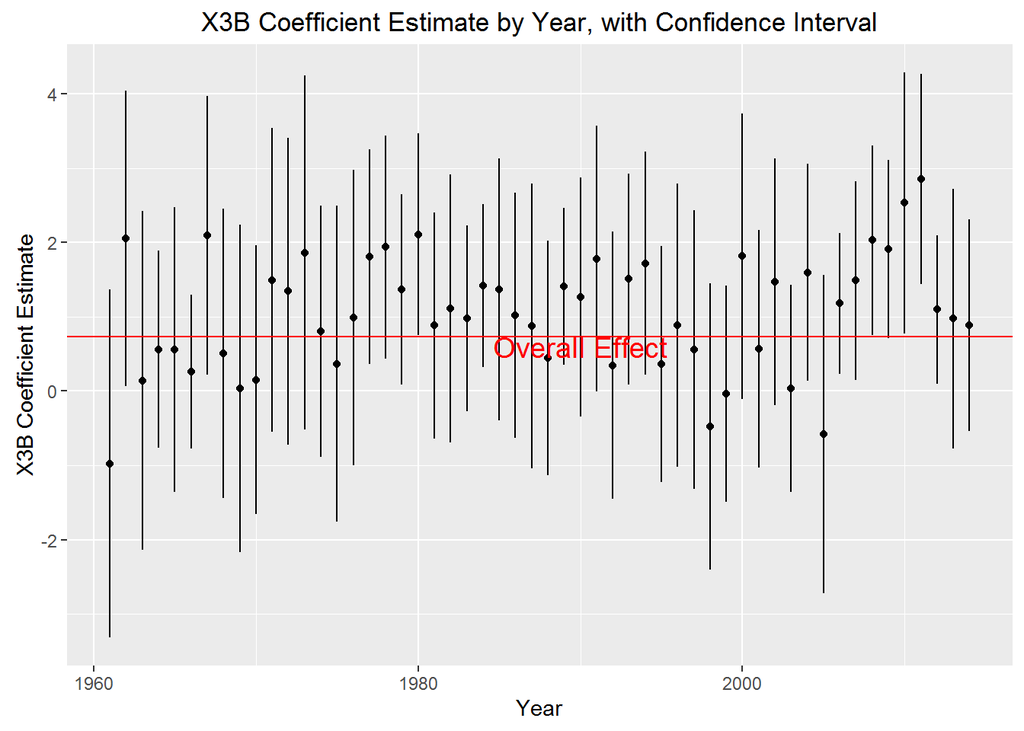

```r
# X3B:
plot.yearly%>%
          filter(term=="X3B")%>%
          ggplot(aes(x=yearID,y=estimate))+
          geom_point()+
          geom_segment(aes(x = yearID, y = X2.5.., xend = yearID, yend = X97.5..))+theme(legend.position = "bottom")+
          labs(x="Year",y="X3B Coefficient Estimate",title="X3B Coefficient Estimate by Year, with Confidence Interval")+
          geom_hline(yintercept =fit$coefficients['X2B'],col="red" )+
          annotate("text", x = 1990, y = 0.6, label = "Overall Effect",col='red',size=5)
```

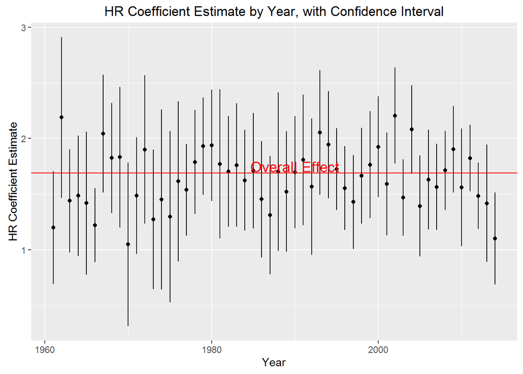

```r
# HR:
plot.yearly%>%
          filter(term=="HR")%>%
          ggplot(aes(x=yearID,y=estimate))+
          geom_point()+
          geom_segment(aes(x = yearID, y = X2.5.., xend = yearID, yend = X97.5..))+theme(legend.position = "bottom")+
          labs(x="Year",y="HR Coefficient Estimate",title="HR Coefficient Estimate by Year, with Confidence Interval")+
          geom_hline(yintercept =fit$coefficients['HR'],col="red" )+
          annotate("text", x = 1990, y = 1.75, label = "Overall Effect",col='red',size=5)
```

# Problem 2 (20% of grade)

In Problem 1 we learned how much BB, singles, extra base hits and home runs help predict runs. Now we want to see how much these costs. Note that batting average, Hits (H) divided by at bats (AB) receive much attention while bases on balls (BB) does not. However, we saw how BB have almost the same effect on runs as singles. Therefore, it is possible that players that receive many BB and do not hit many singles may be undervalued. Before studying this specific question, we will examine if teams can use money to improve.

In general, does spending money help a teams win? Here we will compute the payroll for each team each year. This information is not directly provided. But we have the salary for each player and we also what team they played each year.

Before we get started there is some data wrangling to be done.

```r
## We can use ifelse if you have not seen the revalue function
# in package plyr, revalue: Replace specified values with new values, in a factor or character vector.
mySalaries <- Salaries %>%
  mutate(teamID = as.character(plyr::revalue(teamID, c(SFG = "SFN", NYM = "NYN"))))
```

## Problem 2A

Use the `mySalaries` data to compute each team’s payroll, in millions of dollars, for each team during each year. Save this into an object called `payroll`. Hints: Group by team and year and then sum all salaries. As a sanity check make a plot of payroll against year with color representing teams. Payroll should be increasing with the New York Yankees (code NYA) having the largest payroll. Consider plotting salaries in the log-scale.

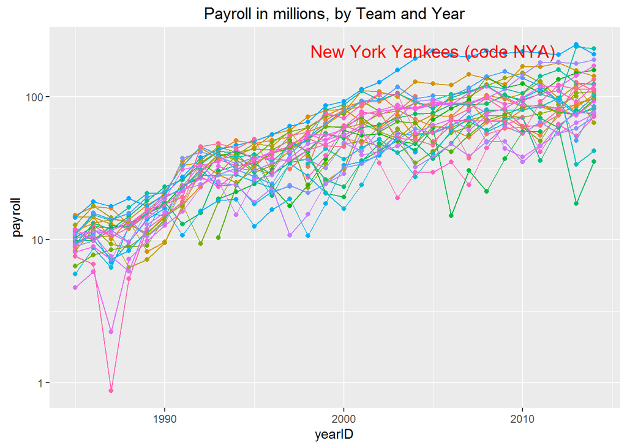

```r
# detach(package:plyr)
payroll <- mySalaries%>%
          group_by(teamID, yearID) %>%
          summarise(payroll=sum(as.numeric(salary))/1000000)%>%
          ungroup()

# As a sanity check make a plot of payroll against year with color representing teams.
payroll %>% ggplot(aes(x=yearID, y=payroll, colour=teamID)) +
            geom_point()+geom_line()+scale_y_log10()+
            theme(legend.position='none')+
            ggtitle("Payroll in millions, by Team and Year")+
            annotate("text", x = 2005, y =filter(payroll, teamID=='NYA'&yearID==2005)$payroll, label = "New York Yankees (code NYA)",col='red',size=5)
```

## Problem 2B

Now add the team’s winning percentage, wins / (wins + losses) for each year to the `payroll` table. Hints: The `Teams` table has wins and losses for each team for each year. The `dplyr` `join` functions permit you to join by two columns.

```r
payroll <- Teams %>%
          select(name, teamID, yearID, W, L) %>%
          right_join(payroll, by=c("teamID", "yearID"))%>%
          mutate(Winpct=W/(W+L))
```

## Problem 2C

Explore the relationship between payroll and winning percentage. Use data visualization to describe what you think is the relationship. Hint: Make scatter plots for, say, 9 different years and add a regression line.

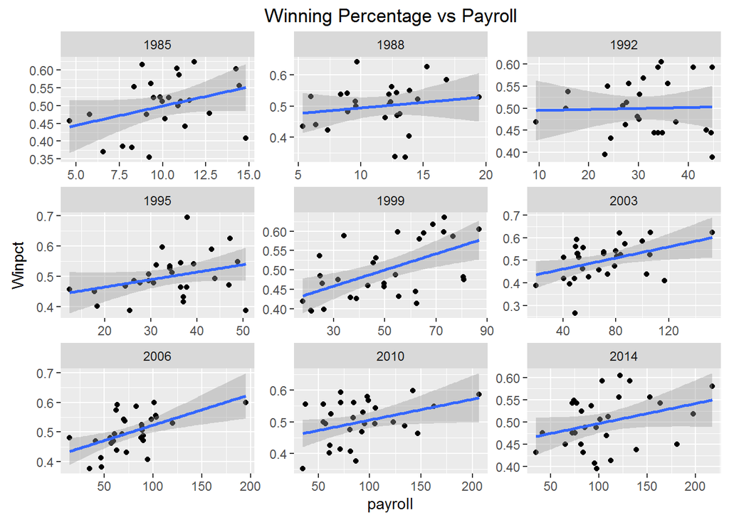

```r
# select 9 year
yr <- floor(seq(min(payroll$yearID),max(payroll$yearID),length.out=9))

# Make scatter plots, add regression line
payroll %>% filter(yearID %in% yr) %>%
            ggplot(aes(x=payroll, y=Winpct)) +
            geom_point() +
            geom_smooth(method=lm) +
            facet_wrap('yearID',scales ="free") +
            ggtitle("Winning Percentage vs Payroll")
```

> I think hihger payroll does have a positive effect on winning percentage, at least there is a clear positive correlation (association).

## Problem 2D

Use the `lm` function to fit a linear model to the 1999 data. Use the log-transform for the payroll data. According to this fitted model, on average, how many more wins does a team improve every time their budget doubles? Provide a 95% confidence interval.

```r
# Since we are interested in doubling budget, take a log2-transform for payroll would yield natural interpretation
fit <-  payroll %>%
        filter(yearID==1999) %>%
        mutate(log2payroll=log2(payroll)) %>%
        lm(formula=W~ log2payroll,data=.)

# Report coefficients
summary(fit)$coef
```

```
##             Estimate Std. Error  t value    Pr(>|t|)
## (Intercept) 23.41955  16.228179 1.443141 0.160075984
## log2payroll 10.45011   2.929428 3.567287 0.001322804
```

```r
# Report confidence interval
confint(fit)
```

```
##                 2.5 %   97.5 %
## (Intercept) -9.822366 56.66147
## log2payroll  4.449448 16.45077
```

> For every time budget doubles, the team is expected to win 10.45 (p-value=0.0013 <.05) more games per year. And the ocnfidence interval is between (4.45, 16.45).

## Problem 2E

Did the Oakland A’s outperform during the Money Ball era? Notice that after Oakland’s original success, other teams started implementing their approach. If in fact they were over-performing then they were winning more than predicted by the regression model.

Fit a linear model to the wins versus standardized data for each year. Then plot the residuals for Oakland. Make the same plot for the Boston Red Sox. (Hint: use the `augment` function from broom on each linear fit object to extract the residuals- look at the documentation for `augment.lm`). What year do you think Oakland started using data science and when did other teams catch up?

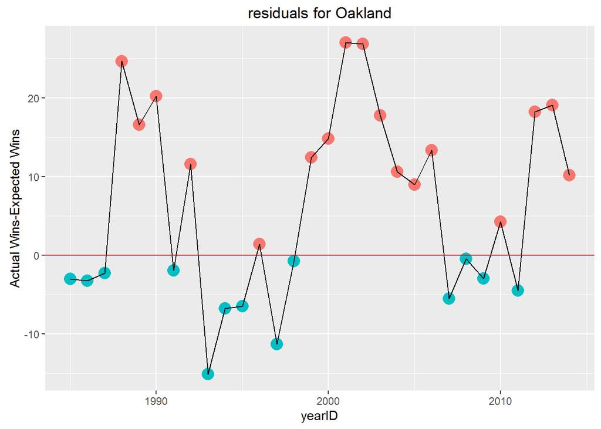

```r
# 'augment': Given an R statistical model or other non-tidy object, add columns to the original dataset such as predictions, residuals and cluster assignments.

dat2E  <-payroll %>%
        mutate(log2payroll=log2(payroll))

# We have seen from previous question that payroll has a consistent positive effect on Wins, we cam assume it's same across years, build a model regress on log2payroll and factor(yearID), and get residual=actual wins - expected wins
res <-dat2E%>%
        lm(formula=W ~ log2payroll + factor(yearID),data=.)%>%
        augment(data=dat2E) %>%
        mutate(perf=ifelse(.resid>0, "Higher than expected", "Lower than expected"))

# plot the residuals for oakland over time
res %>% filter(teamID=='OAK')%>%
        ggplot(aes(x=yearID, y=.resid)) +
        geom_point(aes(col=perf, size=3)) +
        geom_line( ) +
        geom_hline(yintercept=0, col='red') +
        ggtitle("residuals for Oakland") + ylab("Actual Wins-Expected Wins") + theme(legend.position='none')
```

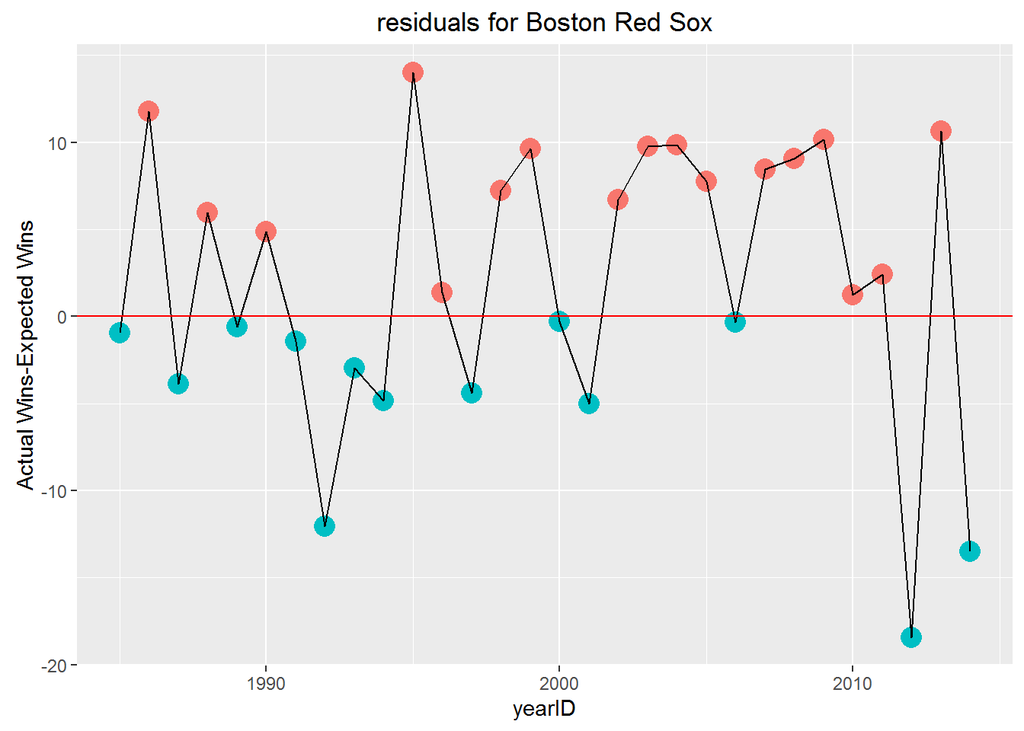

```r
# plot the residuals for Boston Red Sox over time
res %>% filter(teamID=='BOS')%>%
        ggplot(aes(x=yearID, y=.resid)) +
        geom_point(aes(col=perf, size=3)) +
        geom_line() +
        geom_hline(yintercept=0, col='red') +
        ggtitle("residuals for Boston Red Sox") + ylab("Actual Wins-Expected Wins")+ theme(legend.position='none')
```

> I think from 1999 Oakland started using data science, because it had higher than expected wins from then on; from 2007 other teams catch up, because from then on, Oakland’s wins drop back to average level, which might be an indication that others performs better.

## Problem 2F

Since 2000 which team has performed the best over what was expected given their payroll?

```r
res %>%
  filter(yearID>=2000)%>%
  group_by(yearID) %>%
  arrange(desc(.resid))%>%
  filter(row_number()==1)%>%
  select(yearID, teamID, name, .resid)
```

```
## Source: local data frame [15 x 4]
## Groups: yearID [15]
##
##    yearID teamID                          name   .resid
##     (int)  (chr)                         (chr)    (dbl)
## 1    2000    CHA             Chicago White Sox 19.07192
## 2    2001    SEA              Seattle Mariners 32.93835
## 3    2002    OAK             Oakland Athletics 26.85372
## 4    2003    OAK             Oakland Athletics 17.77038
## 5    2004    SLN           St. Louis Cardinals 21.16741
## 6    2005    CLE             Cleveland Indians 16.88653
## 7    2006    MIN               Minnesota Twins 16.16781
## 8    2007    CLE             Cleveland Indians 17.05067
## 9    2008    TBA                Tampa Bay Rays 22.44593
## 10   2009    FLO               Florida Marlins 14.33357
## 11   2010    SDN              San Diego Padres 17.12843
## 12   2011    ARI          Arizona Diamondbacks 17.68497
## 13   2012    WAS          Washington Nationals 18.32894
## 14   2013    OAK             Oakland Athletics 19.06672
## 15   2014    LAA Los Angeles Angels of Anaheim 14.82712
```

## Problem 2G

For each of the BB, singles, extra bases, home runs and stolen bases per game how did Oakland rank in 2002?

```r
# Rank for BB
Teams %>%
  mutate(BB=BB/G, Singles=(H-X2B-X3B-HR)/G, X2B=X2B/G, X3B=X3B/G, HR = HR / G, SB=SB/G) %>%
  filter(yearID==2002)%>%
  mutate(rank=row_number(desc(BB)))%>%
  filter(teamID=="OAK")%>%
  select(name, rank)
```

```
##                name rank
## 1 Oakland Athletics    6
```

```r
# Rank for Singles
Teams %>%
  mutate(BB=BB/G, Singles=(H-X2B-X3B-HR)/G, X2B=X2B/G, X3B=X3B/G, HR = HR / G, SB=SB/G) %>%
  filter(yearID==2002)%>%
  mutate(rank=row_number(desc(Singles)))%>%
  filter(teamID=="OAK")%>%
  select(name, rank)
```

```
##                name rank
## 1 Oakland Athletics   19
```

```r
# Rank for X2B
Teams %>%
  mutate(BB=BB/G, Singles=(H-X2B-X3B-HR)/G, X2B=X2B/G, X3B=X3B/G, HR = HR / G, SB=SB/G) %>%
  filter(yearID==2002)%>%
  mutate(rank=row_number(desc(X2B)))%>%
  filter(teamID=="OAK")%>%
  select(name, rank)
```

```
##                name rank
## 1 Oakland Athletics   23
```

```r
# Rank for X3B
Teams %>%
  mutate(BB=BB/G, Singles=(H-X2B-X3B-HR)/G, X2B=X2B/G, X3B=X3B/G, HR = HR / G, SB=SB/G) %>%
  filter(yearID==2002)%>%
  mutate(rank=row_number(desc(X3B)))%>%
  filter(teamID=="OAK")%>%
  select(name, rank)
```

```
##                name rank
## 1 Oakland Athletics   21
```

```r
# Rank for HR
Teams %>%
  mutate(BB=BB/G, Singles=(H-X2B-X3B-HR)/G, X2B=X2B/G, X3B=X3B/G, HR = HR / G, SB=SB/G) %>%
  filter(yearID==2002)%>%
  mutate(rank=row_number(desc(HR)))%>%
  filter(teamID=="OAK")%>%
  select(name, rank)
```

```
##                name rank
## 1 Oakland Athletics    4
```

```r
# Rank for SB
Teams %>%
  mutate(BB=BB/G, Singles=(H-X2B-X3B-HR)/G, X2B=X2B/G, X3B=X3B/G, HR = HR / G, SB=SB/G) %>%
  filter(yearID==2002)%>%
  mutate(rank=row_number(desc(SB)))%>%
  filter(teamID=="OAK")%>%
  select(name, rank)
```

```
##                name rank
## 1 Oakland Athletics   30
```

> In 2002, Oakland ranked 6th, 19th, 23th, 21th, 4th, 30th, in terms of BB, singles, extra bases, home runs and stolen bases per game, out of total 30 teams.

# Problem 3 (Bonus)

Now we are going to build a baseball team for the 2002 season. We get to pick one of each of the 9 batting positions DH, C, 1B, 2B, 3B, SS, CF and two outfielders (OF, LF, or RF). We will pick players active in 2002 but you will have to pay each player whatever their maximum salary was during their entire career. You have a total of $50 million. Show us your team and how many runs you think they will produce. Note the number of runs per games of the best teams:

```r
Teams %>%
  filter(yearID == 2002, lgID == "AL") %>%
  mutate(runs_per_game = R / G) %>%
  select(teamID, W, L, runs_per_game) %>%
  arrange(desc(W))
```

```
##    teamID   W   L runs_per_game
## 1     NYA 103  58      5.571429
## 2     OAK 103  59      4.938272
## 3     ANA  99  63      5.253086
## 4     MIN  94  67      4.770186
## 5     BOS  93  69      5.302469
## 6     SEA  93  69      5.024691
## 7     CHA  81  81      5.283951
## 8     TOR  78  84      5.018519
## 9     CLE  74  88      4.561728
## 10    TEX  72  90      5.203704
## 11    BAL  67  95      4.117284
## 12    KCA  62 100      4.549383
## 13    DET  55 106      3.571429
## 14    TBA  55 106      4.180124
```

Some hints:

1. You can create a table with per-plate-appearance statistics. For example here is such a table for players that started their career after 1961 and retired by after 2002. It also contains the median year in their career.

```r
res <- Batting %>%
  group_by(playerID) %>%
  filter(max(yearID) <= 2002 & min(yearID) > 1961) %>%
  mutate(PA = AB + BB) %>%
  filter(sum(PA) > 1000) %>%
  summarize(BB = sum(BB) / sum(PA),
            Singles = sum(H - X2B - X3B - HR) / sum(PA),
            XB = sum(X2B + X3B) / sum(PA),
            HR = sum(HR) / sum(PA),
            year = floor(median(yearID)))
```

2. You can add max salary and other player statistics using the `dplyr` join functions.
3. You can use aggregate statistics to build a predictor of runs produced for a team based exclusively on BB, singles, extra base hits, and HR. We did this above:

```r
fit <- Teams %>%
  filter(yearID >= 1961) %>%
  mutate(R = R / G, BB = BB / G,
         Singles = (H - X2B - X3B - HR) / G,
         XB = (X2B + X3B) / G, HR = HR / G) %>%
  lm(R ~ BB + Singles + XB + HR, data = .)
```

4. Create a predicted runs for each player that answers the question: what happens if this player was the only hitter on the team? Focus on players with more than 400 plate appearances that played in 2002. Assume that each team has 6000 plate appearances in each 162 game. From here and from hints 1 and 3 you can create a predicted runs per game statistics for each player. Then look for outliers in terms of producing more runs given their salary.

```r
# Get Players' per-plate-appearance statistics
per.plate <- Batting %>%
            group_by(playerID) %>%
            filter(yearID== 2002 ) %>%
            mutate(PA = AB + BB, BB=BB/PA, Singles=(H - X2B - X3B - HR)/PA, XB=(X2B + X3B)/PA, HR=HR/PA) %>%
            filter(PA > 400)

# Get max salary for each player during entire career, and do log2-transform
max.salary <-Salaries %>%
             group_by(playerID) %>%
             summarise(payroll=max(as.numeric(salary)))%>%
             mutate(log2payroll=log2(payroll))%>%
             select(playerID, payroll,log2payroll)


# Focus on players with more than 400 plate appearances that played in 2002, they are our candidates!
candidate <-per.plate %>%
            left_join(max.salary, by="playerID")%>%
             select(playerID, payroll,log2payroll, BB, Singles, XB, HR )


# Build prediction model for runs per game:R ~ BB + Singles + XB + HR
fit <- Teams %>%
  filter(yearID >= 1961) %>%
  mutate(R = R /(6000*G), BB = BB /(6000*G),
         Singles = (H - X2B - X3B - HR) /(6000*G),
         XB = (X2B + X3B)/(6000*G), HR = HR /(6000*G)) %>%
  lm(R ~ BB + Singles + XB + HR, data = .)

summary(fit) # Note: R-squred 0.9286, extremely high!!!
```

```
##
## Call:
## lm(formula = R ~ BB + Singles + XB + HR, data = .)
##
## Residuals:
##        Min         1Q     Median         3Q        Max
## -8.463e-05 -1.614e-05 -4.260e-07  1.611e-05  9.127e-05
##
## Coefficients:
##               Estimate Std. Error t value Pr(>|t|)
## (Intercept) -4.720e-04  1.221e-05  -38.66   <2e-16 ***
## BB           3.636e-01  1.001e-02   36.31   <2e-16 ***
## Singles      5.546e-01  1.040e-02   53.30   <2e-16 ***
## XB           7.700e-01  1.774e-02   43.40   <2e-16 ***
## HR           1.399e+00  2.055e-02   68.09   <2e-16 ***
## ---
## Signif. codes:  0 '***' 0.001 '**' 0.01 '*' 0.05 '.' 0.1 ' ' 1
##
## Residual standard error: 2.55e-05 on 1411 degrees of freedom
## Multiple R-squared:  0.9286, Adjusted R-squared:  0.9284
## F-statistic:  4589 on 4 and 1411 DF,  p-value: < 2.2e-16
```

```r
# Apply prediciton model, for each player(assume they are the only player in team), predict runs per game
predR <-augment(fit, newdata=candidate )%>%
        mutate(pred.R=.fitted) %>%
        select(playerID, payroll,log2payroll, pred.R)

# Regress predicted runs per game on max salary, look at residual, this helps us know given the salary, who is likely to perform better, a positive residual means that the player is likely to perform better than expected based on salary.
pred.performance  <- predR %>%
                    lm(formula=pred.R~log2payroll, data=.)%>%
                    augment(data=predR)%>%
                    mutate(runs_per_game=.fitted*6000/162, residual_runs_per_game=.resid*6000/162)
```

5. The `lp` function in the `lpSolve` package may be useful for optimizing a team. But you can also do it in an ad-hoc fashion. Once you are done with your team, use the regression fit above to predict the number of runs per game your team will produce.

```r
library(lpSolve)

f.obj <- as.vector(pred.performance$R)
f.con <- matrix (c(rep(1,length(f.obj)), as.vector(pred.performance$payroll)), nrow=2, byrow=TRUE)
f.dir <- c('==','<=')
f.rhs <- c(9, 50000000)
lp ('max', f.obj, f.dir, f.rhs, all.bin=TRUE)
```

> lp doesn’t work, error message: Unknown constraint direction found. We are going to use alternative way.

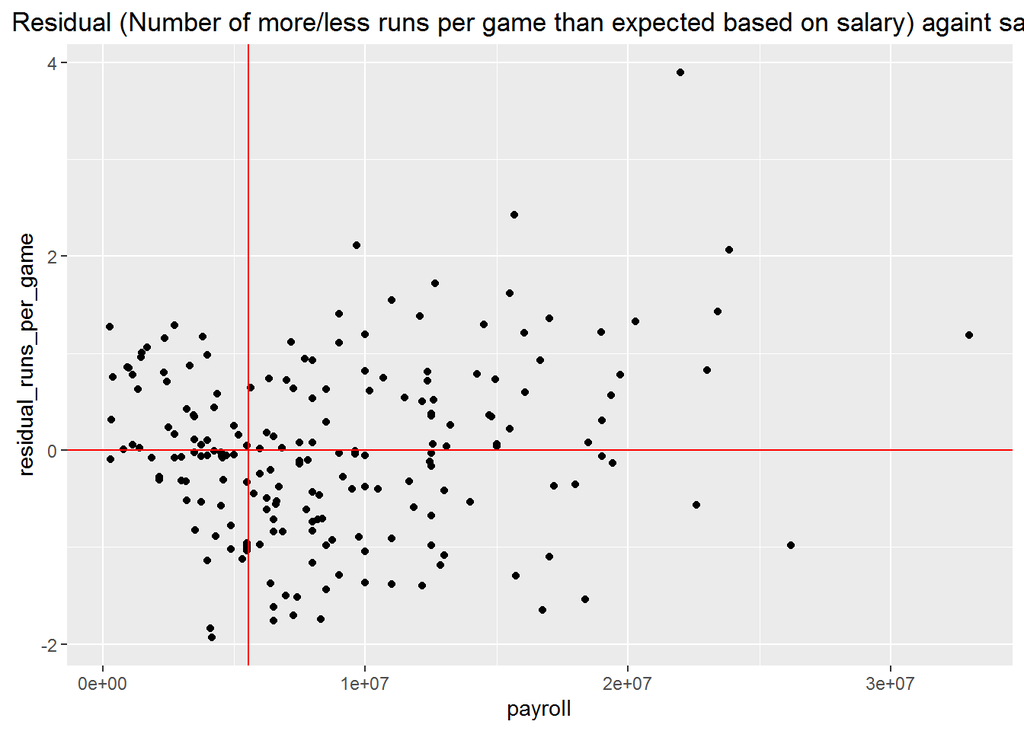

```r
# Plot Residual (Number of more/less runs per game than expected based on salary) againt salary
pred.performance %>%
                 ggplot(aes(x=payroll, y=residual_runs_per_game))+
                 geom_point()+
                 geom_vline(xintercept=50000000/9,col='red')+
                 geom_hline(yintercept = 0, col='red')+
                 ggtitle("Residual (Number of more/less runs per game than expected based on salary) againt salary")
```

```r
pred.performance%>%
  filter(payroll<=50000000/9)%>%
  arrange(desc(residual_runs_per_game))%>%
  filter(row_number()<=9)%>%
  select(playerID, payroll, runs_per_game, residual_runs_per_game)
```

```
##    playerID payroll runs_per_game residual_runs_per_game
## 1 bellhma01 2750000      7.244366              1.2861782
## 2   coxst01  280000      5.924736              1.2713238
## 3 millake01 3800000      7.431172              1.1676081
## 4 spiveju01 2367500      7.157857              1.1535342
## 5 perryhe01 1700000      6.966543              1.0582497
## 6  blumge01 1500000      6.894245              1.0024623
## 7 fullmbr01 4000000      7.460800              0.9801317
## 8 simonra01 1475000      6.884537              0.9591820
## 9 hernajo01 3333333      7.355486              0.8764934
```

```r
# Our team total payroll, predicted Runs per game, and extra Runs than expected based on salary, would be:
pred.performance%>%
  filter(payroll<=50000000/9)%>%
  arrange(desc(residual_runs_per_game))%>%
  filter(row_number()<=9)%>%
  summarise(sum(payroll), mean(runs_per_game), mean(residual_runs_per_game))
```

```
##   sum(payroll) mean(runs_per_game) mean(residual_runs_per_game)
## 1     21205833            7.035527                     1.083907
```

> We only spend $21,205,833, to have the highest runs per game (~7) than what we saw at the beginning of Problem 3!